# Факторный анализ данных car2004

## Загрузка данных

```r
data_car <- read_excel("C:/Users/redmi/OneDrive/Документы/R analysis/car2004.xls", na = "*")
colnames(data_car) <- gsub("-", "_", colnames(data_car))

# Добавление доп.столбцов
data_car$Other <- ifelse(rowSums(data_car[c("Sport", "SportUtil", "Wagon", "Minivan", "Pickup")]) == 0, 1, 0)
data_car$Front_wheel <- ifelse(rowSums(data_car[c("All_wheel", "Rear_wheel")]) == 0, 1, 0)

# Создание категориальных переменных
data_car <- data_car %>%
mutate(
  Body_type = factor(case_when(
    Sport == 1 ~ 1,
    SportUtil == 1 ~ 2,
    Wagon == 1 ~ 3,
    Minivan == 1 ~ 4,
    Pickup == 1 ~ 5,
    Other == 1 ~ 6,
    TRUE ~ NA_integer_
  ), levels = c(1, 2, 3, 4, 5, 6), labels = c("Sport", "SportUtil", "Wagon", "Minivan", "Pickup", "Other"))
)

data_car <- data_car %>%
  mutate(
    Wheel_type = factor(case_when(
      All_wheel == 1 ~ 1,
      Rear_wheel == 1 ~ 2,
      Front_wheel == 1 ~ 3,
      TRUE ~ NA_integer_
    ), levels = c(1, 2, 3), labels = c("All_wheel", "Rear_wheel", "Front_wheel"))
  )

head(data_car, 5) |>
 print_df()
```

| Name | Sport | SportUtil | Wagon | Minivan | Pickup | All_wheel | Rear_wheel | Retail | Dealer | Engine | Cylinders | Horsepower | CityMPG | HW_MPG | Weight | WheelBase | Length | Width | Other | Front_wheel | Body_type | Wheel_type |
| --- | --- | --- | --- | --- | --- | --- | --- | --- | --- | --- | --- | --- | --- | --- | --- | --- | --- | --- | --- | --- | --- | --- |
| Chevrolet Aveo 4dr | 0 | 0 | 0 | 0 | 0 | 0 | 0 | 11690 | 10965 | 1.6 | 4 | 103 | 28 | 34 | 2370 | 98 | 167 | 66 | 1 | 1 | Other | Front_wheel |
| Chevrolet Aveo LS 4dr hatch | 0 | 0 | 0 | 0 | 0 | 0 | 0 | 12585 | 11802 | 1.6 | 4 | 103 | 28 | 34 | 2348 | 98 | 153 | 66 | 1 | 1 | Other | Front_wheel |
| Chevrolet Cavalier 2dr | 0 | 0 | 0 | 0 | 0 | 0 | 0 | 14610 | 13697 | 2.2 | 4 | 140 | 26 | 37 | 2617 | 104 | 183 | 69 | 1 | 1 | Other | Front_wheel |
| Chevrolet Cavalier 4dr | 0 | 0 | 0 | 0 | 0 | 0 | 0 | 14810 | 13884 | 2.2 | 4 | 140 | 26 | 37 | 2676 | 104 | 183 | 68 | 1 | 1 | Other | Front_wheel |
| Chevrolet Cavalier LS 2dr | 0 | 0 | 0 | 0 | 0 | 0 | 0 | 16385 | 15357 | 2.2 | 4 | 140 | 26 | 37 | 2617 | 104 | 183 | 69 | 1 | 1 | Other | Front_wheel |

1. *Name* - Название автомобиля - **качественный признак**
2. *Sport* - Спортивная машина (1=да, 0=нет) - **качественный признак** Легкие, обычно имеют мощные двигатели, способные развивать высокие скорости, чаще всего имеют задний или полный привод.
3. *SportUtil* - Внедорожник (тип кузова) (1=да, 0=нет) - **качественный признак** Характеризуется высокой посадкой, вместительным салоном, большим клиренсом и возможностью полного привода.
4. *Wagon* - Универсал (тип кузова) (1=да, 0=нет) - **качественный признак** Характеризуется увеличенным багажным отсеком, обычно имеет передний или полный привод.
5. *Minivan* - Минивэн (тип кузова) (1=да, 0=нет) - **качественный признак** Характеризуется большим количеством места для пассажиров и багажа, наиболее характерен передний привод. Некоторые модели минивэнов предлагают неплохую экономию топлива, учитывая их размер и вместительность.
6. *Pickup* - Пикап (тип кузова) (1=да, 0=нет) - **качественный признак** Характеризуется мощными двигателями и возможностью заднего или полного приводов.
7. *All-wheel* - Полный привод (1=да, 0=нет) - **качественный признак**
8. *Rear-wheel* - Задний привод (1=да, 0=нет) - **качественный признак**
9. *Retail* - Рекомендованная розничная цена в долларах (цена продажи диллером) - **количественный непрерывный**
10. *Dealer* - Закупочная цена для дилера в долларах - **количественный непрерывный**
11. *Engine* - Объем двигателя в литрах - **количественный дискретный**
12. *Cylinders* - Число цилиндров (=-1 для роторного двигателя) - **количественный дискретный**
13. *Horsepower* - Лошадиные силы - **количественный дискретный**
14. *CityMPG* - Ожидаемый пробег в милях на галлон топлива для автомобиля в условиях городского движения. - **количественный дискретный**
15. *HW_MPG* - Ожидаемый пробег в милях на галлон топлива для автомобиля в условиях движения по шоссе или трассе при постоянной скорости - **количественный дискретный**

В городском цикле обычно встречаются частые остановки, старты и пробки, что приводит к более частому использованию тормозов и ускорителей. Это может уменьшить экономию топлива.

В условиях шоссейного движения меньше остановок и меньше стартов, что может способствовать более высокой экономии топлива.

То есть ожидается, что HW_MPG > CityMPG.

16. *Weight* - Вес автомобиля в фунтах - **количественный непрерывный**
17. *WheelBase* - Расстояние между передними и задними колесами в дюймах - **количественный дискретный**
18. *Length* - Длина автомобиля в дюймах - **количественный дискретный**
19. *Width* - Ширина автомобиля в дюймах - **количественный дискретный**

Были добавлены еще два столбца, которые соответствуют другому (то есть ни одному из представленных) типу кузова (*Other*) и переднему приводу (*Front_wheel*).

Также были добавлены две категориальные переменные, отвечающие типу кузова (*Body_type*) и типу привода (*Wheel_type*).

Наблюдения Retail, Dealer, Engine, Horsepower, CityMPG, HW_MPG, Weight, WheelBase имеют хвост вправо, прологарифмируем их и построим графики зависимостей признаков.

```r
data_log <- data_car %>%
  mutate_at(vars(Retail, Dealer, Engine, Horsepower, CityMPG, HW_MPG, Weight, WheelBase), ~log(.))

data_select <- data_log %>% dplyr::select(-Name, -Sport, -SportUtil,-Wagon, -Minivan, -Pickup, -All_wheel, -Rear_wheel, -Cylinders, -Other, -Front_wheel, -Body_type, -Wheel_type)

#create_ggpairs(data_select, density_diag = FALSE)
```

Так как пропусков не так много, то заполним их медианным значением по каждому признаку.

```r
cols_to_fill <- c("CityMPG", "HW_MPG", "Weight", "WheelBase", "Length", "Width")
filled_cols <- na.aggregate(data_log[, cols_to_fill], FUN = median, na.rm = TRUE)
data_log[, cols_to_fill] <- filled_cols
```

## Результат факторного анализа

### Оценка количества факторов

#### Корреляционная плеяда

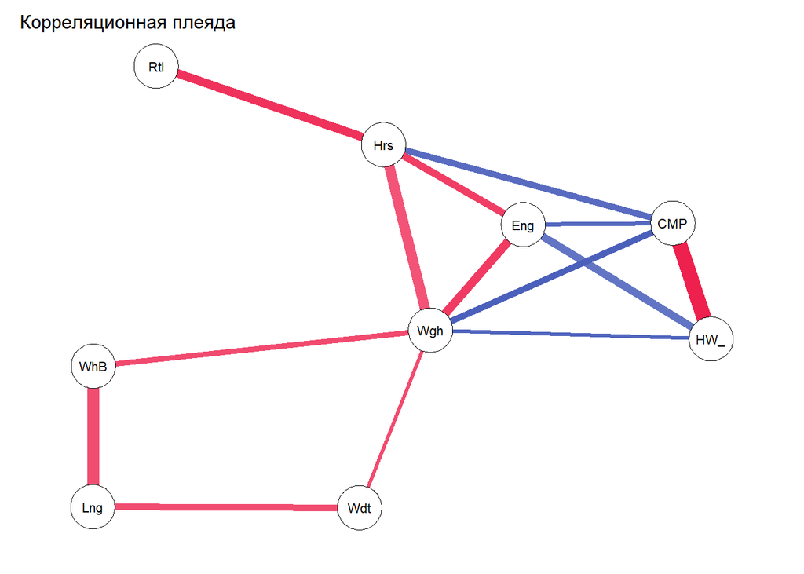

```r
data_fa <- data_log %>% dplyr::select(Retail, HW_MPG, WheelBase, Width, Length, Weight, Horsepower, Engine, CityMPG)

data_fa_std <- data_fa %>%
  mutate_at(vars(Retail:CityMPG), ~(.-mean(.))/sd(.))

cor_matrix <- cor(data_fa_std)

qgraph(cor_matrix, layout = "spring",
       edge.color = ifelse(cor_matrix > 0, "#ee204d", "#324ab2"),
       edge.width = abs(cor_matrix),
       vsize = 6,
       label.cex = 0.9,
       threshold = 0.7,
       title = "Корреляционная плеяда")
```

Можно выделить три скрытые переменные:

1. **Размеры машины**: объединяет признаки WheelBase, Length, Width;
2. **Характеристики мотора** (мощность и экономичность): Weight, Engine, Horsepower, HW_MPG, CityMPG;
3. **Стоимость машины**: Retail.

#### Параллельный анализ

Работает следующим образом:

- Создание случайных данных: Сначала создается набор случайных данных с такой же структурой, как исходные данные.
- Факторный анализ случайных данных: Затем проводится факторный анализ на этих случайных данных.
- Сравнение собственных значений: Собственные значения из факторного анализа реальных данных сравниваются с собственными значениями из факторного анализа случайных данных.
- Определение числа факторов: Число факторов – это количество собственных значений реальных данных, которые больше, чем соответствующие собственные значения случайных данных.

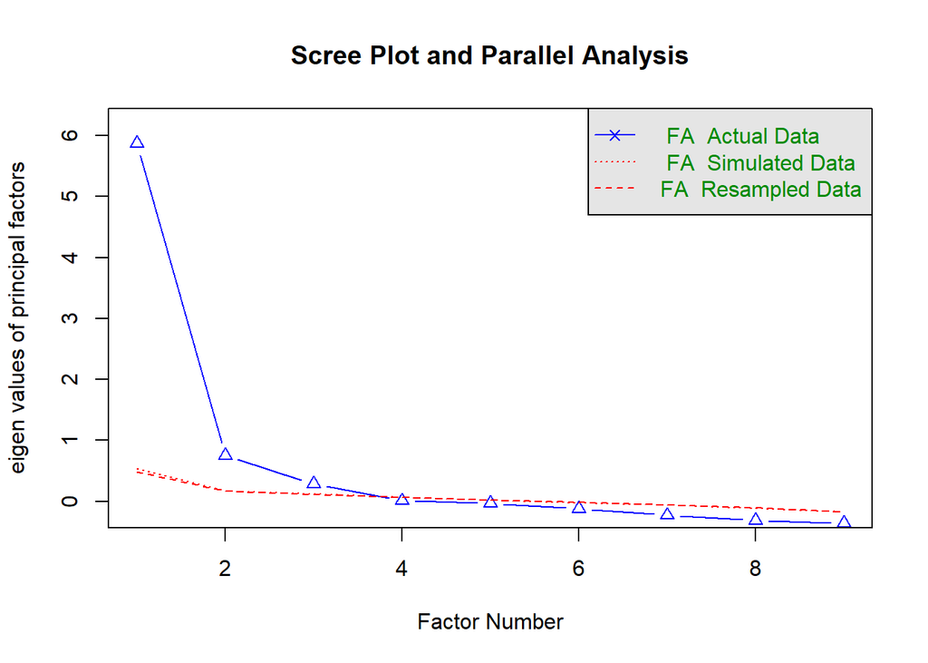

```
## Parallel analysis suggests that the number of factors =  3  and the number of components =  NA
```

```r
set.seed(1234)

fa.parallel(data_fa_std,
            fa = "fa",
            fm = "minres",
            show.legend = TRUE,
            main = "Scree Plot and Parallel Analysis")
```

На основе данного графика можно попробовать сделать трехфакторный анализ.

Задача корректна, так как при $p=9$, $r=3$ неравенство выполняется:

$$\frac{(p-r)^2-(p+r)}{2}\geqslant 0 \quad
\text{так как} \quad \frac{(9-3)^2-(9+3)}{2}=12.$$

### Трехфакторный анализ

```r
efa3_none <- fa(cor_matrix,
               nfactors=3,
               rotate="none",
               fm="ml")
print(efa3_none,
      cut = 0.5)
```

```
## Factor Analysis using method =  ml
## Call: fa(r = cor_matrix, nfactors = 3, rotate = "none", fm = "ml")
## Standardized loadings (pattern matrix) based upon correlation matrix
##              ML1   ML2   ML3   h2     u2 com
## Retail      0.60  0.57       0.81 0.1878 2.6
## HW_MPG     -0.99             1.00 0.0049 1.0
## WheelBase   0.56        0.56 0.74 0.2634 2.6
## Width       0.60             0.70 0.2964 2.6
## Length            0.54  0.61 0.83 0.1691 2.7
## Weight      0.84             0.88 0.1164 1.5
## Horsepower  0.73  0.59       0.95 0.0512 2.2
## Engine      0.77             0.82 0.1776 1.7
## CityMPG    -0.96             0.93 0.0673 1.0
##
##                        ML1  ML2  ML3
## SS loadings           4.94 1.59 1.14
## Proportion Var        0.55 0.18 0.13
## Cumulative Var        0.55 0.72 0.85
## Proportion Explained  0.64 0.21 0.15
## Cumulative Proportion 0.64 0.85 1.00
##
## Mean item complexity =  2
## Test of the hypothesis that 3 factors are sufficient.
##
## df null model =  36  with the objective function =  10.98
## df of  the model are 12  and the objective function was  0.43
##
## The root mean square of the residuals (RMSR) is  0.02
## The df corrected root mean square of the residuals is  0.03
##
## Fit based upon off diagonal values = 1
## Measures of factor score adequacy
##                                                    ML1  ML2  ML3
## Correlation of (regression) scores with factors   1.00 0.97 0.93
## Multiple R square of scores with factors          1.00 0.94 0.87
## Minimum correlation of possible factor scores     0.99 0.88 0.74
```

**Диаграмма факторных нагрузок**

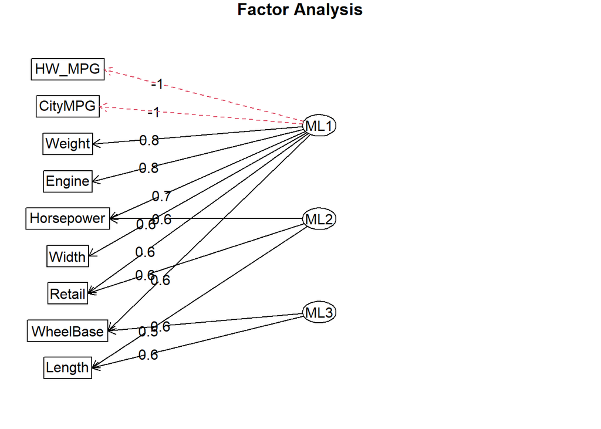

```r
fa.diagram(efa3_none, cut=.5, simple = FALSE)
```

При отсутствии вращения факторы неинтерпретируемы.

#### varimax (ортогональное вращение)

Максимизация варимакс критерия соответствует максимизации дисперсий квадратов нагрузок факторов. Тем самым теоретическая сложность фактора уменьшается, нагрузки фактора близки к 0 или 1, и фактор можно наилучшим образом проинтерпретировать. Нормализация факторных нагрузок в данном критерии устраняет различие между вкладами отдельных параметров пропорциональное их общностям.

```r
efa3_varimax <- fa(cor_matrix,
               nfactors=3,
               rotate="varimax",
               fm="ml")
print(efa3_varimax,
      cut = 0.5)
```

```
## Factor Analysis using method =  ml
## Call: fa(r = cor_matrix, nfactors = 3, rotate = "varimax", fm = "ml")
## Standardized loadings (pattern matrix) based upon correlation matrix
##              ML3   ML2   ML1   h2     u2 com
## Retail            0.85       0.81 0.1878 1.3
## HW_MPG                 -0.91 1.00 0.0049 1.4
## WheelBase   0.79             0.74 0.2634 1.4
## Width       0.72             0.70 0.2964 1.7
## Length      0.89             0.83 0.1691 1.1
## Weight      0.62        0.58 0.88 0.1164 2.7
## Horsepower        0.86       0.95 0.0512 1.6
## Engine      0.54  0.58       0.82 0.1776 2.9
## CityMPG                -0.78 0.93 0.0673 2.0
##
##                        ML3  ML2  ML1
## SS loadings           2.89 2.40 2.37
## Proportion Var        0.32 0.27 0.26
## Cumulative Var        0.32 0.59 0.85
## Proportion Explained  0.38 0.31 0.31
## Cumulative Proportion 0.38 0.69 1.00
##
## Mean item complexity =  1.8
## Test of the hypothesis that 3 factors are sufficient.
##
## df null model =  36  with the objective function =  10.98
## df of  the model are 12  and the objective function was  0.43
##
## The root mean square of the residuals (RMSR) is  0.02
## The df corrected root mean square of the residuals is  0.03
##
## Fit based upon off diagonal values = 1
## Measures of factor score adequacy
##                                                    ML3  ML2  ML1
## Correlation of (regression) scores with factors   0.95 0.96 0.99
## Multiple R square of scores with factors          0.90 0.92 0.98
## Minimum correlation of possible factor scores     0.80 0.85 0.96
```

**Диаграмма факторных нагрузок**

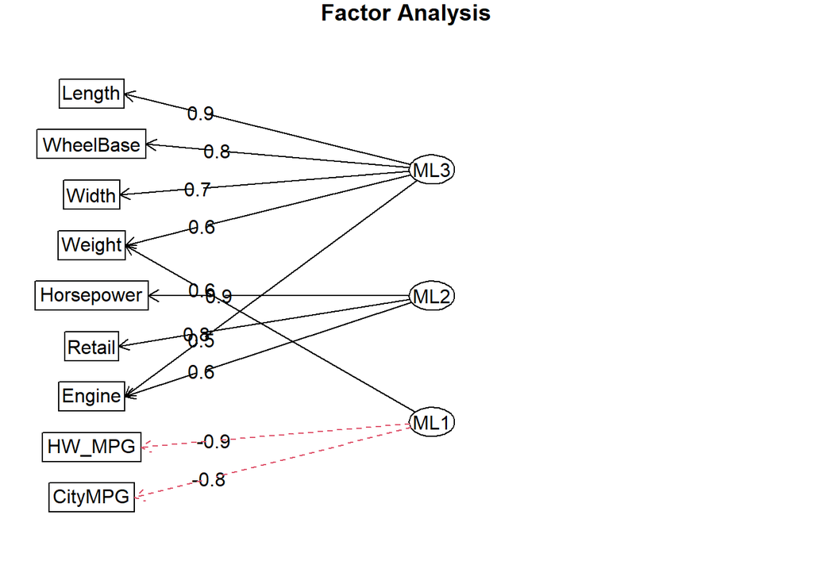

```r
fa.diagram(efa3_varimax, cut=.5, simple = FALSE)
```

**Интерпретация факторов**

ML3 (Размер): WheelBase, Length, Width, Weight, Engine – признаки, связанные с размерами автомобиля.

ML2 (Производительность): Retail, Horsepower, Engine – признаки, связанные с производительностью автомобиля.

ML1 (Топливная эффективность): HW_MPG, CityMPG, Weight – признаки, связанные с топливной экономичностью.

#### oblimin (косоугольное вращение)

Oblimin использует алгоритм, который поворачивает факторы так, чтобы сумма квадратов внедиагональных элементов матрицы корреляций факторов была минимизирована. При этом не требуется, чтобы факторы были независимыми.

```r
efa3_oblimin <- fa(cor_matrix,
               nfactors=3,
               rotate="oblimin",
               fm="ml")
print(efa3_oblimin,
      cut = 0.5)
```

```
## Factor Analysis using method =  ml
## Call: fa(r = cor_matrix, nfactors = 3, rotate = "oblimin", fm = "ml")
## Standardized loadings (pattern matrix) based upon correlation matrix
##              ML3   ML1   ML2   h2     u2 com
## Retail                  0.96 0.81 0.1878 1.0
## HW_MPG            1.03       1.00 0.0049 1.0
## WheelBase   0.80             0.74 0.2634 1.2
## Width       0.70             0.70 0.2964 1.1
## Length      0.97             0.83 0.1691 1.1
## Weight                       0.88 0.1164 2.2
## Horsepower              0.90 0.95 0.0512 1.0
## Engine                       0.82 0.1776 2.5
## CityMPG           0.78       0.93 0.0673 1.1
##
##                        ML3  ML1  ML2
## SS loadings           2.82 2.48 2.37
## Proportion Var        0.31 0.28 0.26
## Cumulative Var        0.31 0.59 0.85
## Proportion Explained  0.37 0.32 0.31
## Cumulative Proportion 0.37 0.69 1.00
##
##  With factor correlations of
##       ML3   ML1   ML2
## ML3  1.00 -0.53  0.50
## ML1 -0.53  1.00 -0.66
## ML2  0.50 -0.66  1.00
##
## Mean item complexity =  1.4
## Test of the hypothesis that 3 factors are sufficient.
##
## df null model =  36  with the objective function =  10.98
## df of  the model are 12  and the objective function was  0.43
##
## The root mean square of the residuals (RMSR) is  0.02
## The df corrected root mean square of the residuals is  0.03
##
## Fit based upon off diagonal values = 1
## Measures of factor score adequacy
##                                                    ML3  ML1  ML2
## Correlation of (regression) scores with factors   0.96 1.00 0.98
## Multiple R square of scores with factors          0.93 1.00 0.96
## Minimum correlation of possible factor scores     0.86 0.99 0.92
```

**Диаграмма факторных нагрузок**

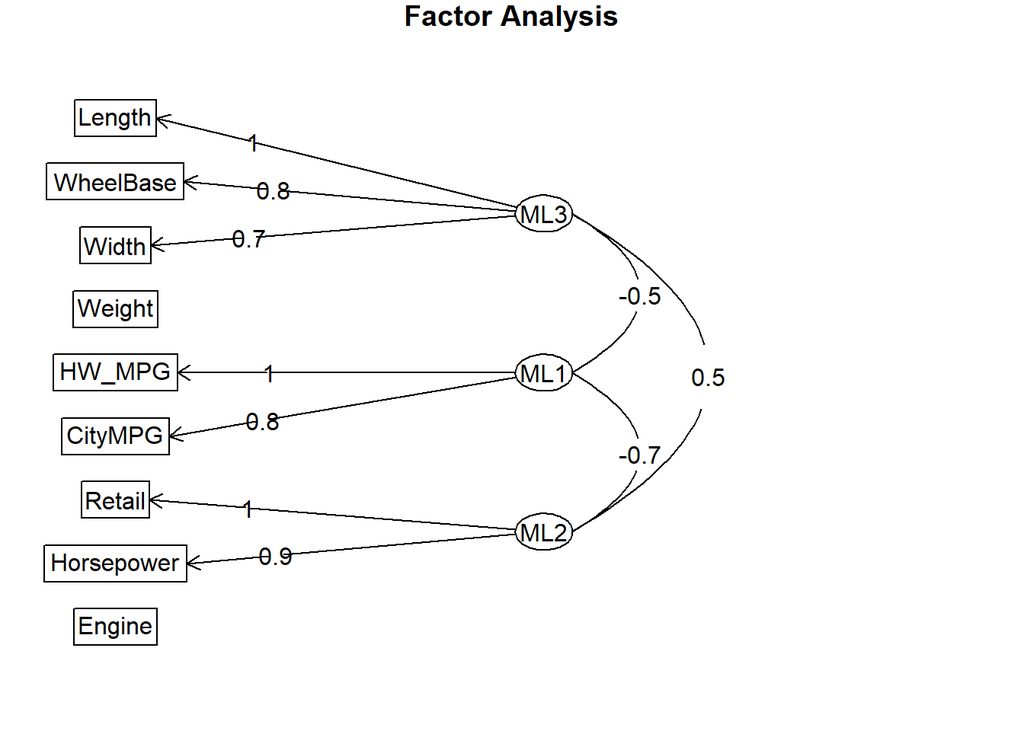

```r
fa.diagram(efa3_oblimin, cut=.5, simple = FALSE)
```

**Интерпретация факторов**

ML3 (Размер): WheelBase, Length, Width – признаки, связанные с размерами автомобиля.

ML1 (Топливная эффективность): HW_MPG, CityMPG – признаки, связанные с топливной экономичностью.

ML2 (Производительность): Retail, Horsepower – признаки, связанные с производительностью автомобиля.

### Двухфакторный анализ

```r
efa2_none <- fa(cor_matrix,
               nfactors=2,
               rotate="none",
               scores="regression",
               fm="minires")
print(efa2_none,
      cut = 0.4)
```

```
## Factor Analysis using method =  minres
## Call: fa(r = cor_matrix, nfactors = 2, rotate = "none", scores = "regression",
##     fm = "minires")
## Standardized loadings (pattern matrix) based upon correlation matrix
##              MR1   MR2   h2   u2 com
## Retail      0.70       0.64 0.36 1.6
## HW_MPG     -0.81       0.70 0.30 1.2
## WheelBase   0.73  0.43 0.72 0.28 1.6
## Width       0.78       0.69 0.31 1.3
## Length      0.70  0.55 0.79 0.21 1.9
## Weight      0.95       0.90 0.10 1.0
## Horsepower  0.84       0.83 0.17 1.3
## Engine      0.91       0.82 0.18 1.0
## CityMPG    -0.89       0.84 0.16 1.1
##
##                        MR1  MR2
## SS loadings           5.97 0.96
## Proportion Var        0.66 0.11
## Cumulative Var        0.66 0.77
## Proportion Explained  0.86 0.14
## Cumulative Proportion 0.86 1.00
##
## Mean item complexity =  1.3
## Test of the hypothesis that 2 factors are sufficient.
##
## df null model =  36  with the objective function =  10.98
## df of  the model are 19  and the objective function was  2.37
##
## The root mean square of the residuals (RMSR) is  0.06
## The df corrected root mean square of the residuals is  0.08
##
## Fit based upon off diagonal values = 0.99
## Measures of factor score adequacy
##                                                    MR1  MR2
## Correlation of (regression) scores with factors   0.99 0.91
## Multiple R square of scores with factors          0.98 0.82
## Minimum correlation of possible factor scores     0.96 0.65
```

**Диаграмма факторных нагрузок**

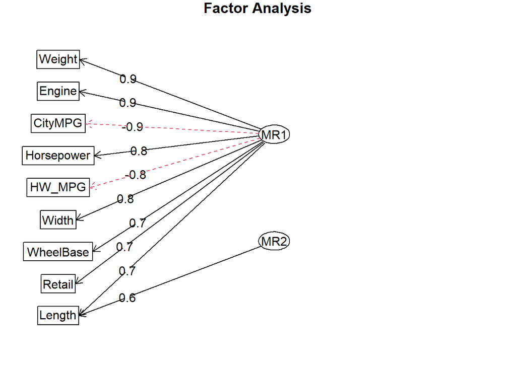

```r
fa.diagram(efa2_none, cut=.5, simple = FALSE)
```

Как и в случае с трехфакторным анализом, при отсутствии вращения факторы неинтерпретируемы.

```r
efa2_varimax <- fa(cor_matrix,
               nfactors=2,
               rotate="varimax",
               fm="minires")
print(efa2_varimax,
      cut = 0.5)
```

```
## Factor Analysis using method =  minres
## Call: fa(r = cor_matrix, nfactors = 2, rotate = "varimax", fm = "minires")
## Standardized loadings (pattern matrix) based upon correlation matrix
##              MR1   MR2   h2   u2 com
## Retail      0.78       0.64 0.36 1.1
## HW_MPG     -0.76       0.70 0.30 1.4
## WheelBase         0.80 0.72 0.28 1.3
## Width             0.72 0.69 0.31 1.6
## Length            0.87 0.79 0.21 1.1
## Weight      0.68  0.66 0.90 0.10 2.0
## Horsepower  0.87       0.83 0.17 1.2
## Engine      0.73  0.54 0.82 0.18 1.9
## CityMPG    -0.83       0.84 0.16 1.4
##
##                        MR1  MR2
## SS loadings           3.93 3.00
## Proportion Var        0.44 0.33
## Cumulative Var        0.44 0.77
## Proportion Explained  0.57 0.43
## Cumulative Proportion 0.57 1.00
##
## Mean item complexity =  1.4
## Test of the hypothesis that 2 factors are sufficient.
##
## df null model =  36  with the objective function =  10.98
## df of  the model are 19  and the objective function was  2.37
##
## The root mean square of the residuals (RMSR) is  0.06
## The df corrected root mean square of the residuals is  0.08
##
## Fit based upon off diagonal values = 0.99
## Measures of factor score adequacy
##                                                    MR1  MR2
## Correlation of (regression) scores with factors   0.96 0.94
## Multiple R square of scores with factors          0.93 0.88
## Minimum correlation of possible factor scores     0.86 0.75
```

#### varimax (ортогональное вращение)

**Диаграмма факторных нагрузок**

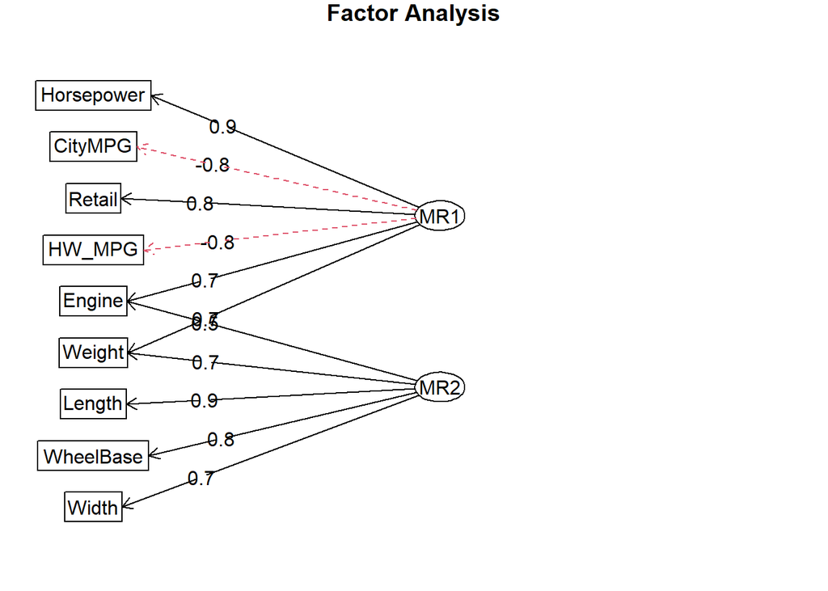

```r
fa.diagram(efa2_varimax, cut=.5, simple = FALSE)
```

**Интерпретация факторов**

MR1 (Мощность и экономичность): Retail, Horsepower, Engine, Weight, CityMPG, HW_MPG – все эти характеристики так или иначе связаны с мощностью автомобиля. Логично, что чем более мощная машина, тем скорее всего больше ее вес и стоимость, и тем меньше MPG.

MR2 (Габариты автомобиля): Engine, Weight, Length, WheelBase, Width – характеристики, связанные с размерами машины.

#### oblimin (косоугольное вращение)

```r
efa2_oblimin <- fa(cor_matrix,
               nfactors=2,
               rotate="oblimin",
               fm="minires")
print(efa2_oblimin,
      cut = 0.5)
```

```
## Factor Analysis using method =  minres
## Call: fa(r = cor_matrix, nfactors = 2, rotate = "oblimin", fm = "minires")
## Standardized loadings (pattern matrix) based upon correlation matrix
##              MR1   MR2   h2   u2 com
## Retail      0.89       0.64 0.36 1.1
## HW_MPG     -0.79       0.70 0.30 1.0
## WheelBase         0.81 0.72 0.28 1.0
## Width             0.66 0.69 0.31 1.3
## Length            0.94 0.79 0.21 1.0
## Weight      0.59       0.90 0.10 1.9
## Horsepower  0.95       0.83 0.17 1.0
## Engine      0.68       0.82 0.18 1.4
## CityMPG    -0.86       0.84 0.16 1.0
##
##                        MR1  MR2
## SS loadings           4.29 2.64
## Proportion Var        0.48 0.29
## Cumulative Var        0.48 0.77
## Proportion Explained  0.62 0.38
## Cumulative Proportion 0.62 1.00
##
##  With factor correlations of
##     MR1 MR2
## MR1 1.0 0.6
## MR2 0.6 1.0
##
## Mean item complexity =  1.2
## Test of the hypothesis that 2 factors are sufficient.
##
## df null model =  36  with the objective function =  10.98
## df of  the model are 19  and the objective function was  2.37
##
## The root mean square of the residuals (RMSR) is  0.06
## The df corrected root mean square of the residuals is  0.08
##
## Fit based upon off diagonal values = 0.99
## Measures of factor score adequacy
##                                                    MR1  MR2
## Correlation of (regression) scores with factors   0.99 0.96
## Multiple R square of scores with factors          0.97 0.92
## Minimum correlation of possible factor scores     0.95 0.84
```

**Диаграмма факторных нагрузок**

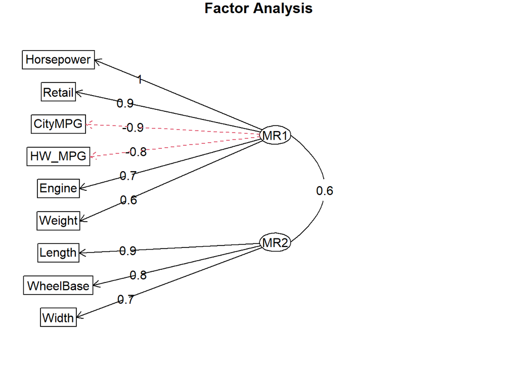

```r
fa.diagram(efa2_oblimin, cut=.5, simple = FALSE)
```

В данном случае факторы можно интерпретировать аналогично случаю вращения varimax.